# Отчет по проекту_2

### 0. Организационная часть

Для работы над проектом подгружаем датафрейм *Boston* из пакета **MASS**

```r
data(Boston)
```

Список используемых в работе библиотек: **MASS**, **dplyr**, **ggplot2**, **gridExtra**, **car**, **cowplot**.

### 1. Знакомство с данными и их предобработка

Посмотрим на наши данные, их структуру, есть ли пропущенные значения:

```r
options(width = 100)
head(Boston)
```

```
##      crim zn indus chas   nox    rm  age    dis rad tax ptratio  black lstat medv
## 1 0.00632 18  2.31    0 0.538 6.575 65.2 4.0900   1 296    15.3 396.90  4.98 24.0
## 2 0.02731  0  7.07    0 0.469 6.421 78.9 4.9671   2 242    17.8 396.90  9.14 21.6
## 3 0.02729  0  7.07    0 0.469 7.185 61.1 4.9671   2 242    17.8 392.83  4.03 34.7
## 4 0.03237  0  2.18    0 0.458 6.998 45.8 6.0622   3 222    18.7 394.63  2.94 33.4
## 5 0.06905  0  2.18    0 0.458 7.147 54.2 6.0622   3 222    18.7 396.90  5.33 36.2
## 6 0.02985  0  2.18    0 0.458 6.430 58.7 6.0622   3 222    18.7 394.12  5.21 28.7
```

```r
str(Boston)
```

```
## 'data.frame':    506 obs. of  14 variables:
##  $ crim   : num  0.00632 0.02731 0.02729 0.03237 0.06905 ...
##  $ zn     : num  18 0 0 0 0 0 12.5 12.5 12.5 12.5 ...
##  $ indus  : num  2.31 7.07 7.07 2.18 2.18 2.18 7.87 7.87 7.87 7.87 ...
##  $ chas   : int  0 0 0 0 0 0 0 0 0 0 ...
##  $ nox    : num  0.538 0.469 0.469 0.458 0.458 0.458 0.524 0.524 0.524 0.524 ...
##  $ rm     : num  6.58 6.42 7.18 7 7.15 ...
##  $ age    : num  65.2 78.9 61.1 45.8 54.2 58.7 66.6 96.1 100 85.9 ...
##  $ dis    : num  4.09 4.97 4.97 6.06 6.06 ...
##  $ rad    : int  1 2 2 3 3 3 5 5 5 5 ...
##  $ tax    : num  296 242 242 222 222 222 311 311 311 311 ...
##  $ ptratio: num  15.3 17.8 17.8 18.7 18.7 18.7 15.2 15.2 15.2 15.2 ...
##  $ black  : num  397 397 393 395 397 ...
##  $ lstat  : num  4.98 9.14 4.03 2.94 5.33 ...
##  $ medv   : num  24 21.6 34.7 33.4 36.2 28.7 22.9 27.1 16.5 18.9 ...
```

```r
colSums(is.na(Boston))
```

```
##    crim      zn   indus    chas     nox      rm     age     dis     rad     tax ptratio   black
##       0       0       0       0       0       0       0       0       0       0       0       0
##   lstat    medv
##       0       0
```

Переведем переменные **chas** и **rad** в факторные переменные

```r
table(Boston$chas)
```

```
##
##   0   1
## 471  35
```

```r
table(Boston$rad)
```

```
##
##   1   2   3   4   5   6   7   8  24
##  20  24  38 110 115  26  17  24 132
```

```r
Boston$chas <- factor(Boston$chas, levels = c("0", "1"), labels = c("0", "1"))
Boston$rad <- factor(Boston$rad,
                     levels = c("1", "2", "3", "4", "5", "6", "7", "8", "24"),
                     labels = c("1", "2", "3", "4", "5", "6", "7", "8", "24"))
```

### 2. Работа над обязатеьной частью. Пункт 1

Проведем стандартизацию количественных предикторов:

```r
scaled_Boston <- Boston
scaled_Boston[, c(1:3, 5:8, 10:13)] <- scale(scaled_Boston[, c(1:3, 5:8, 10:13)])
```

Отлично! Проверим наличие отскоков с помощью точечных диаграмм Кливленда:

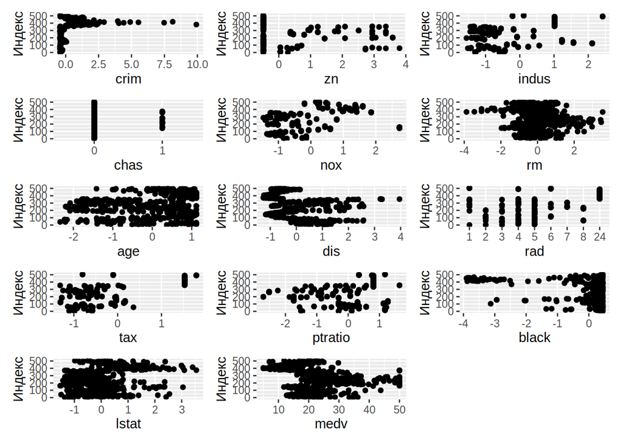

```r
gg_dot <- ggplot(scaled_Boston, aes(y = 1:nrow(scaled_Boston))) + geom_point() + ylab('Индекс')
Pl1 <- gg_dot + aes(x = crim)
Pl2 <- gg_dot + aes(x = zn)
Pl3 <- gg_dot + aes(x = indus)
Pl4 <- gg_dot + aes(x = chas)
Pl5 <- gg_dot + aes(x = nox)
Pl6 <- gg_dot + aes(x = rm)
Pl7 <- gg_dot + aes(x = age)
Pl8 <- gg_dot + aes(x = dis)
Pl9 <- gg_dot + aes(x = rad)
Pl10 <- gg_dot + aes(x = tax)
Pl11 <- gg_dot + aes(x = ptratio)
Pl12 <- gg_dot + aes(x = black)
Pl13 <- gg_dot + aes(x = lstat)
Pl14 <- gg_dot + aes(x = medv)
plot_grid(Pl1, Pl2, Pl3, Pl4, Pl5, Pl6,
          Pl7, Pl8, Pl9, Pl10, Pl11, Pl12, Pl13, Pl14, ncol = 3, nrow = 5) + theme_minimal()
```

Да, есть много отскакивающих значений, но имеет ли право мы их убирать? Я считаю, что нет, поскольку по аннотации данных нам трудно предположить, имела ли место погрешность при сборе данных или это особенность данных из-за наличия автокорреляции.

Строим полную линейную модель без учета взаимодействия предикторов. От себя добавлю, что особенно при появлении дискретных переменных необходимо учитывать взаимодействия дискретных и непрерывных предикторов, так что по-хорошему это сделать нужно для полной модели, но от нас в задании почему-то это не требуется…

```
##
## Call:
## lm(formula = medv ~ ., data = scaled_Boston)
##
## Residuals:
##      Min       1Q   Median       3Q      Max
## -15.1020  -2.7355  -0.4565   1.6821  25.9450
##
## Coefficients:
##             Estimate Std. Error t value Pr(>|t|)
## (Intercept) 18.31176    1.15474  15.858  < 2e-16 ***
## crim        -0.93603    0.28114  -3.329 0.000937 ***
## zn           1.28032    0.32999   3.880 0.000119 ***
## indus        0.16300    0.43665   0.373 0.709081
## chas1        2.52416    0.86318   2.924 0.003614 **
## nox         -2.03633    0.45150  -4.510 8.13e-06 ***
## rm           2.57544    0.29594   8.703  < 2e-16 ***
## age          0.01298    0.37232   0.035 0.972210
## dis         -3.27342    0.42516  -7.699 7.75e-14 ***
## rad2         1.48891    1.47751   1.008 0.314095
## rad3         4.68125    1.33530   3.506 0.000498 ***
## rad4         2.57623    1.18737   2.170 0.030514 *
## rad5         2.91849    1.20761   2.417 0.016028 *
## rad6         1.18584    1.46401   0.810 0.418342
## rad7         4.87899    1.57120   3.105 0.002012 **
## rad8         4.83984    1.49166   3.245 0.001257 **
## rad24        7.46167    1.78868   4.172 3.58e-05 ***
## tax         -1.47439    0.65641  -2.246 0.025144 *
## ptratio     -2.10523    0.31279  -6.731 4.78e-11 ***
## black        0.85761    0.24291   3.531 0.000454 ***
## lstat       -3.77923    0.36162 -10.451  < 2e-16 ***
## ---
## Signif. codes:  0 '***' 0.001 '**' 0.01 '*' 0.05 '.' 0.1 ' ' 1
##
## Residual standard error: 4.694 on 485 degrees of freedom
## Multiple R-squared:  0.7499, Adjusted R-squared:  0.7396
## F-statistic:  72.7 on 20 and 485 DF,  p-value: < 2.2e-16
```

Классно!

### Работа над обязательной часть. Пункт 2. Диагностика модели

#### а) Проверка линейности взаимосвязи

Первым делом можем построить график попарной зависимости всего от всех и посмотреть на потенциальные проблемы:

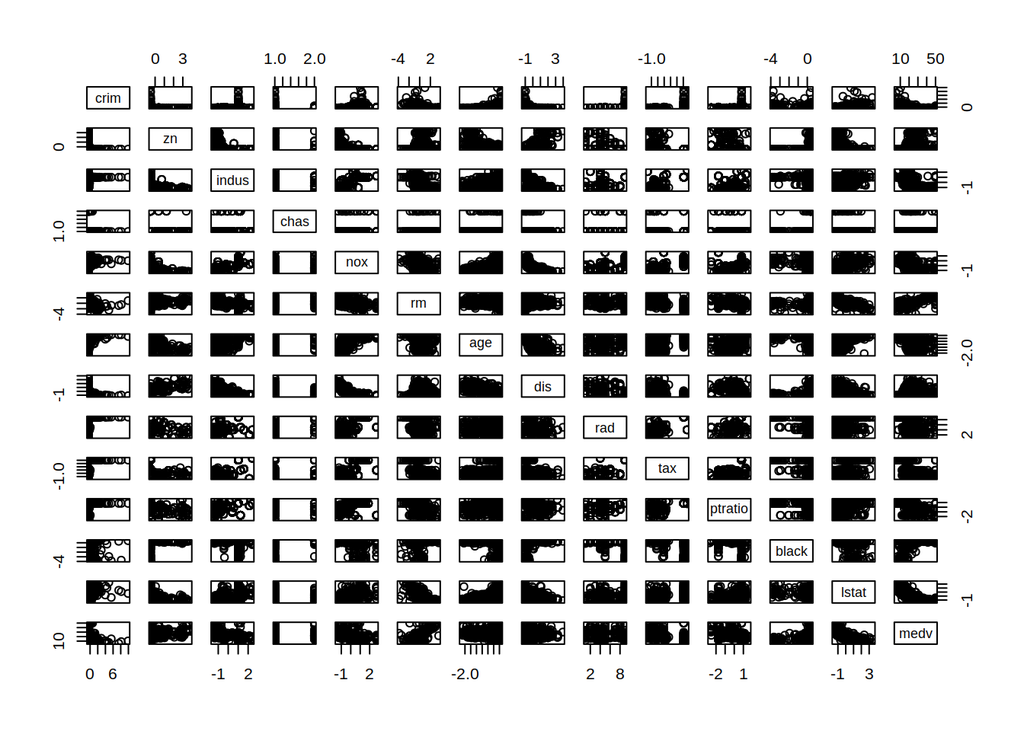

Видим, что проблем хватает почти по всем фронтам. Некоторые переменные, предположительно, взаимосвязаны друг с другом.

Чтобы окончательно удостовериться, есть ли проблемы с нелинейностью связи, посмотрим на график остатков от предсказанных значений:

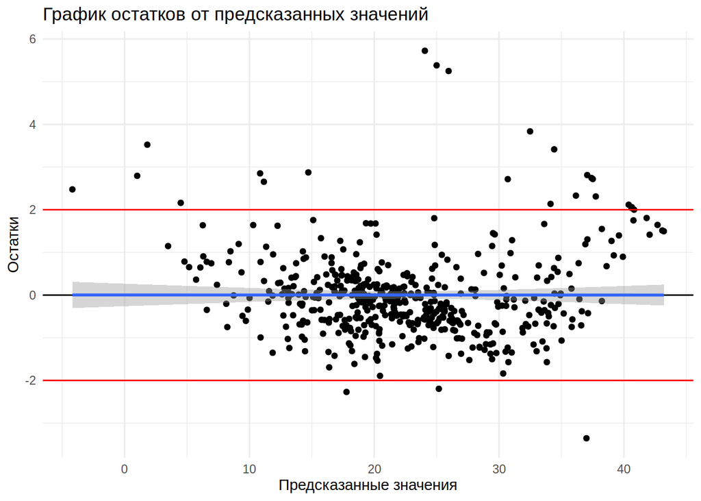

Да, я полагаю, что есть проблемы с нелинейностью взаимосвязи.

#### б) Проверка влиятельных наблюдений с помощью графика расстояний Кука

Расстояние Кука описывает, как повлияет на модель удаление данного наблюдения. Зависит одновременно от величины остатков и силы воздействия наблюдения.  
Как нам выбрать условное пороговое значение?  
Наблюдение будем считать выбросом, если:  
Значение больше единицы (это мягкий порог, но для работы нам его будет достаточно)

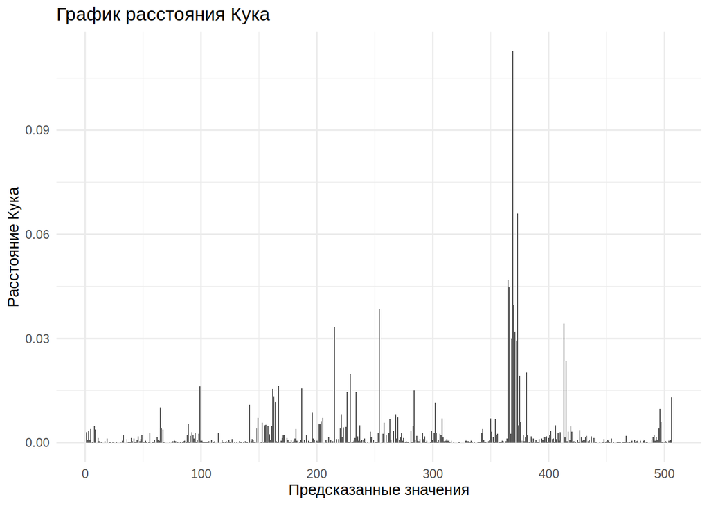

В случае выставления более жесткого порога (4/n - p), где n - объем выборки, p - число параметров, ситуация вырисовывается совсем иная:

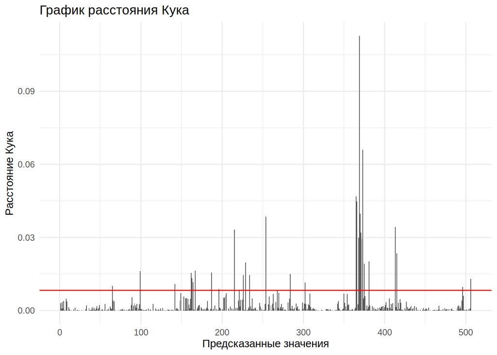

Формально нам ничто не мешает использовать мягкий порог и утвержать, что влиятельные наблюдения у нас отсутствуют.

#### в) Независимость наблюдений (есть ли автокорреляция)

Об автокорреляции имет смысл говорить, если у нас есть ряд наблюдений во времени или пространстве.

Существуют различные способы проверки временной автокорреляции. Например, график автокорреляционной функции остатков (ACF-plot) покажет корреляции с разными лагами. Критерий Дарбина-Уотсона (значимость автокорреляции 1-го порядка). Но эти способы годятся, если наблюдения в ряду расположены через равномерные интервалы. Насколько понятно из датафрейма, временной автокорреляции у нас нет.

Для проверки пространственных автокорреляций можно использовать вариограммы или I Морана, но мы будем использовать способ намного лучше – график остатков от переменных, входящих в модель!

На графике остатков от переменных, входящих в модель и не входящих в нее мы сможем увидеть намного больше, чем наличие автокорреляции – мы видим “паттерны” в широком смысле. Это могут быть не только автокорреляции, но и признаки нелинейной зависимости или невключенных взаимодействий предикторов и т.п.

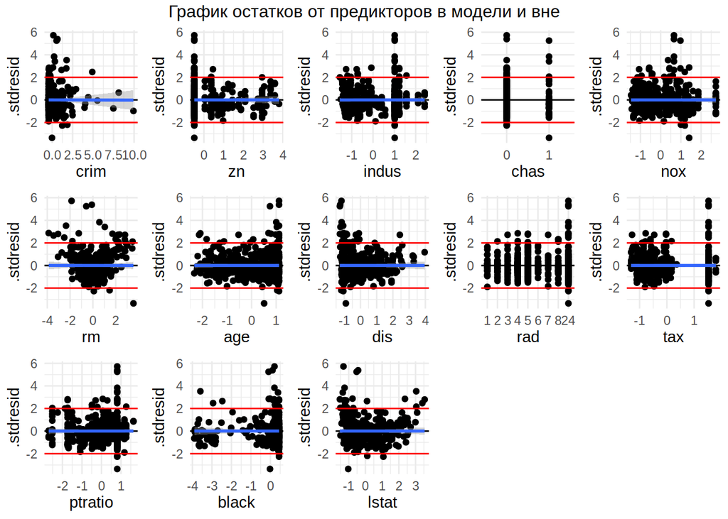

Видим паттерны для многих переменных: с данными не все хорошо. Вполне может быть, что присутствует пространственная автокорреляция в связи с тем, что Бостон – город большой, а переменная, которая бы отражала район, не внесена. В свою очередь зависимости от района благополучность обстановки по разным параметрам может сильно варьировать, оттуда и подозрения на автокорреляцию.

#### г) Проверка на нормальность распределения остатков и постянство дисперсии

Есть формальные тесты на нормальность распределения остатков, но у формальных тестов тоже есть свои условия применимости, при больших выборках они скорее покажут, что значимы даже небольшие отклонения от нормального распределения. Тесты, которые используются в линейной регрессии устойчивы к небольшим отклонениям от нормального распределения, но лучший способ проверки – это квантильный график остатков.

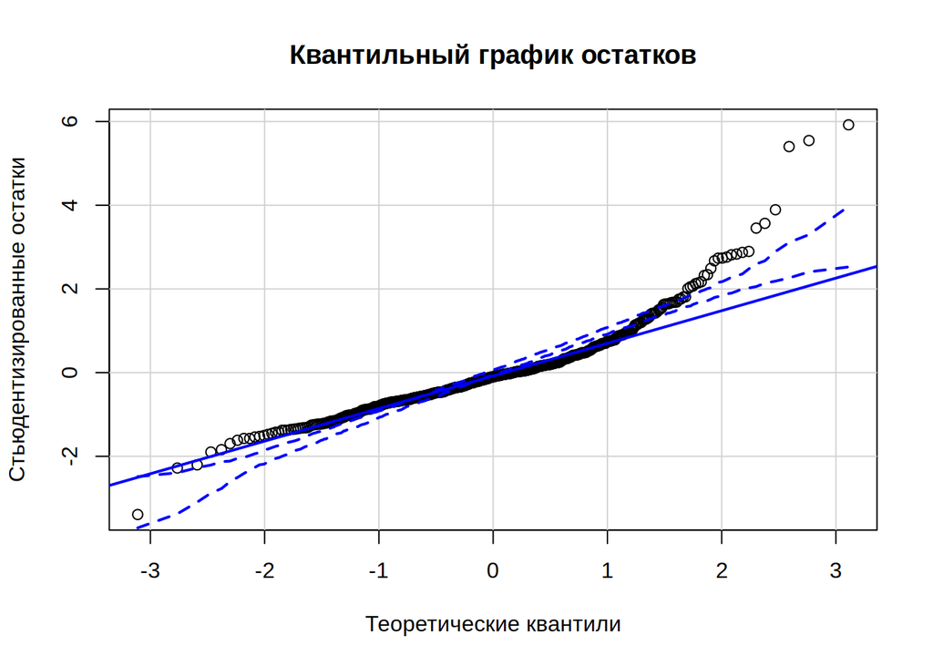

Наконец, одно из самых важных условий: постоянство дисперсии, она же гомогенность дисперсии или гомоскедастичность. Многие тесты чувствительны к гетероскедастичности, поэтому это самое важное условие!

Опять же есть формальные тесты (тест Бройша-Пагана, тест Кокрана), но у формальных тестов тоже есть свои условия применимости, и многие сами неустойчивы к гетероскедастичности. При больших выборках формальные тесты покажут, что значима даже небольшая гетероскедастичность, поэтому лучший способ проверки на гомогенность дисперсий – график остатков, который мы уже строили. Наличие гетероскедастичности еще раз убеждает нас в том, что модель, которую мы изначально построили никуда не годится.

### Работа над обязательной частью. Пункт 3

Поскольку полная модель никуда совершенно не годится, будем строить график предсказанных значений для оптимальной модели!

### Работа над дополнительной частью. Пункт 1

Для начала нужно оценить, какую долю изменчивости конкретного предиктора могут объяснить другие предикторы, т.е. насколько предикторы независимы. Из предыдущих шагов мы выяснили, что возможна проблема с мультиколлинеарностью. Попарный график намекет на то, что может быть линейная зависимость между предикторами. При наличии мультиколлинеарности оценки параметров неточны, а значит сложно интерпретировать влияние предикторов на отклик.

#### Пробуем решить сложность с мультиколлинеарностью

Чтобы исключить такие подводные камни, делаем проверку на мультиколлинеарность подсчетом коэффициента раздутия дисперсии (VIF).

```
##              GVIF Df GVIF^(1/(2*Df))
## crim     1.811867  1        1.346056
## zn       2.496184  1        1.579932
## indus    4.370471  1        2.090567
## chas     1.101843  1        1.049687
## nox      4.672906  1        2.161691
## rm       2.007593  1        1.416896
## age      3.177556  1        1.782570
## dis      4.143583  1        2.035579
## rad     18.783126  8        1.201187
## tax      9.876853  1        3.142746
## ptratio  2.242683  1        1.497559
## black    1.352516  1        1.162977
## lstat    2.997620  1        1.731364
```

Да, в нашей модели сильная мультиколлинеарность. Удаляем предиктор **rad**, поскольку у него самый большой VIF и строим новую модель.

```
##     crim       zn    indus     chas      nox       rm      age      dis      tax  ptratio    black
## 1.664471 2.273018 3.682265 1.061561 4.304929 1.885425 3.083009 3.954951 3.415289 1.734873 1.341459
##    lstat
## 2.937752
```

Теперь удаляем предиктор **nox** и снова перестраиваем модель.

```
##     crim       zn    indus     chas       rm      age      dis      tax  ptratio    black    lstat
## 1.663613 2.266956 3.477127 1.058946 1.875477 2.878244 3.628870 3.095110 1.566568 1.331479 2.921385
```

Все еще есть избыточные предикторы, которые нас не устраивают. Удаляем предиктор **dis**.

```
##     crim       zn    indus     chas       rm      age      tax  ptratio    black    lstat
## 1.637882 1.826807 3.155735 1.057774 1.847368 2.430656 3.073277 1.504126 1.331457 2.920516
```

К сожалению, все еще есть предикторы с коэффициентом раздутия дисперсии больше трех. Если бесконечно выкидывать предикторы до оптимального VIF для всех предикторов, то есть шанс избавиться предиктора, без которого модель станет намного хуже, поэтому все равно нужен компромисс. Попробуем работать с такой моделлью дальше.

#### Пошаговый отбор оптимальной модели

Тестируем значимость всех предикторов за один раз, затем выбираем предиктор, удаление которого меньше всего ухудшает модель:

```
## Single term deletions
##
## Model:
## medv ~ crim + zn + indus + chas + rm + age + tax + ptratio +
##     black + lstat
##         Df Sum of Sq   RSS    AIC  F value    Pr(>F)
## <none>               12903 1660.8
## crim     1     34.14 12937 1660.1   1.3096 0.2530290
## zn       1      1.33 12904 1658.8   0.0511 0.8212179
## indus    1      0.00 12903 1658.8   0.0000 0.9956576
## chas     1    301.81 13205 1670.5  11.5784 0.0007213 ***
## rm       1   2815.58 15718 1758.6 108.0154 < 2.2e-16 ***
## age      1     39.28 12942 1660.3   1.5071 0.2201728
## tax      1      0.44 12903 1658.8   0.0169 0.8965528
## ptratio  1   1104.67 14008 1700.3  42.3789 1.848e-10 ***
## black    1    272.01 13175 1669.3  10.4351 0.0013187 **
## lstat    1   2546.88 15450 1749.9  97.7070 < 2.2e-16 ***
## ---
## Signif. codes:  0 '***' 0.001 '**' 0.01 '*' 0.05 '.' 0.1 ' ' 1
```

Переменную **indus** можно спокойно исключить из модели. Повторяем процедуру:

```
## Single term deletions
##
## Model:
## medv ~ crim + zn + chas + rm + age + tax + ptratio + black +
##     lstat
##         Df Sum of Sq   RSS    AIC  F value    Pr(>F)
## <none>               12903 1658.8
## crim     1     34.49 12937 1658.1   1.3259 0.2500974
## zn       1      1.42 12904 1656.8   0.0545 0.8155276
## chas     1    305.35 13208 1668.6  11.7378 0.0006633 ***
## rm       1   2868.04 15771 1758.3 110.2502 < 2.2e-16 ***
## age      1     41.76 12945 1658.4   1.6051 0.2057761
## tax      1      0.59 12904 1656.8   0.0225 0.8806993
## ptratio  1   1108.15 14011 1698.5  42.5983 1.664e-10 ***
## black    1    272.37 13175 1667.3  10.4701 0.0012942 **
## lstat    1   2566.68 15470 1748.6  98.6654 < 2.2e-16 ***
## ---
## Signif. codes:  0 '***' 0.001 '**' 0.01 '*' 0.05 '.' 0.1 ' ' 1
```

Исключаем **tax**:

```
## Single term deletions
##
## Model:
## medv ~ crim + zn + chas + rm + age + ptratio + black + lstat
##         Df Sum of Sq   RSS    AIC  F value    Pr(>F)
## <none>               12904 1656.8
## crim     1     43.63 12947 1656.5   1.6804 0.1954694
## zn       1      1.28 12905 1654.8   0.0494 0.8242611
## chas     1    305.02 13208 1666.6  11.7484 0.0006595 ***
## rm       1   2867.80 15771 1756.3 110.4581 < 2.2e-16 ***
## age      1     41.84 12945 1656.4   1.6116 0.2048597
## ptratio  1   1246.94 14150 1701.5  48.0282 1.309e-11 ***
## black    1    293.32 13197 1666.2  11.2978 0.0008358 ***
## lstat    1   2605.67 15509 1747.9 100.3617 < 2.2e-16 ***
## ---
## Signif. codes:  0 '***' 0.001 '**' 0.01 '*' 0.05 '.' 0.1 ' ' 1
```

Исключаем **zn**:

```
## Single term deletions
##
## Model:
## medv ~ crim + chas + rm + age + ptratio + black + lstat
##         Df Sum of Sq   RSS    AIC  F value    Pr(>F)
## <none>               12905 1654.8
## crim     1     42.79 12948 1654.5   1.6512 0.1993922
## chas     1    303.86 13209 1664.6  11.7262 0.0006671 ***
## rm       1   2949.54 15854 1757.0 113.8236 < 2.2e-16 ***
## age      1     44.86 12950 1654.6   1.7312 0.1888642
## ptratio  1   1370.25 14275 1703.9  52.8783 1.385e-12 ***
## black    1    294.34 13199 1664.2  11.3588 0.0008092 ***
## lstat    1   2605.96 15511 1745.9 100.5650 < 2.2e-16 ***
## ---
## Signif. codes:  0 '***' 0.001 '**' 0.01 '*' 0.05 '.' 0.1 ' ' 1
```

Возможно, где-то на этом или предыдущем шаге хочется остановиться, помятуя правило “полная модель всегда будет лучше вложенной”, однако попробуем довести дело до конца и посмотреть, что станет с финальной версией модели.

Исключаем **crim**:

```
## Single term deletions
##
## Model:
## medv ~ chas + rm + age + ptratio + black + lstat
##         Df Sum of Sq   RSS    AIC  F value    Pr(>F)
## <none>               12948 1654.5
## chas     1    310.98 13258 1664.5  11.9852 0.0005823 ***
## rm       1   2916.14 15864 1755.3 112.3884 < 2.2e-16 ***
## age      1     38.50 12986 1654.0   1.4839 0.2237394
## ptratio  1   1467.25 14415 1706.8  56.5480 2.568e-13 ***
## black    1    374.02 13322 1666.9  14.4148 0.0001647 ***
## lstat    1   2892.39 15840 1754.5 111.4730 < 2.2e-16 ***
## ---
## Signif. codes:  0 '***' 0.001 '**' 0.01 '*' 0.05 '.' 0.1 ' ' 1
```

Исключаем последний незначимый факток **age**:

```
## Single term deletions
##
## Model:
## medv ~ chas + rm + ptratio + black + lstat
##         Df Sum of Sq   RSS    AIC F value    Pr(>F)
## <none>               12986 1654.0
## chas     1     352.2 13338 1665.6  13.562 0.0002560 ***
## rm       1    3186.1 16172 1763.0 122.672 < 2.2e-16 ***
## ptratio  1    1434.6 14421 1705.0  55.236 4.667e-13 ***
## black    1     364.0 13350 1666.0  14.013 0.0002026 ***
## lstat    1    3611.6 16598 1776.2 139.056 < 2.2e-16 ***
## ---
## Signif. codes:  0 '***' 0.001 '**' 0.01 '*' 0.05 '.' 0.1 ' ' 1
```

Ура! Наша модель готова!

#### Анализ полученной модели

##### Проверка на линейность взаимосвязи с помощью графика остатков предсказанных значений:

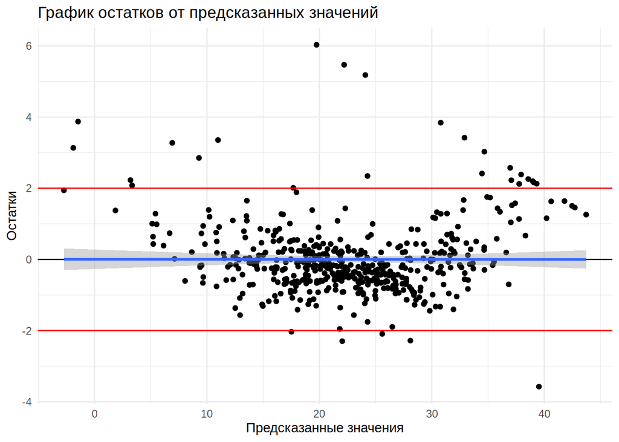

Однозначно видим, что лучше не стало… может ли это быть связано с тем, что мы не дошли до конца с искоренением мультиколлинеарности?..

```
##     chas       rm  ptratio    black    lstat
## 1.019506 1.693576 1.215367 1.182497 1.913747
```

```
##
## Call:
## lm(formula = medv ~ chas + rm + ptratio + black + lstat, data = scaled_Boston)
##
## Residuals:
##      Min       1Q   Median       3Q      Max
## -17.6281  -2.9377  -0.8882   1.5061  30.2533
##
## Coefficients:
##             Estimate Std. Error t value Pr(>|t|)
## (Intercept)  22.3032     0.2350  94.914  < 2e-16 ***
## chas1         3.3200     0.9015   3.683 0.000256 ***
## rm            3.2688     0.2951  11.076  < 2e-16 ***
## ptratio      -1.8581     0.2500  -7.432 4.67e-13 ***
## black         0.9232     0.2466   3.743 0.000203 ***
## lstat        -3.6995     0.3137 -11.792  < 2e-16 ***
## ---
## Signif. codes:  0 '***' 0.001 '**' 0.01 '*' 0.05 '.' 0.1 ' ' 1
##
## Residual standard error: 5.096 on 500 degrees of freedom
## Multiple R-squared:  0.696,  Adjusted R-squared:  0.693
## F-statistic: 228.9 on 5 and 500 DF,  p-value: < 2.2e-16
```

Нет, дело не в этом. Хорошо, идем дальше…

##### Проверка влиятельных наблюдений с помощью графика расстояний Кука

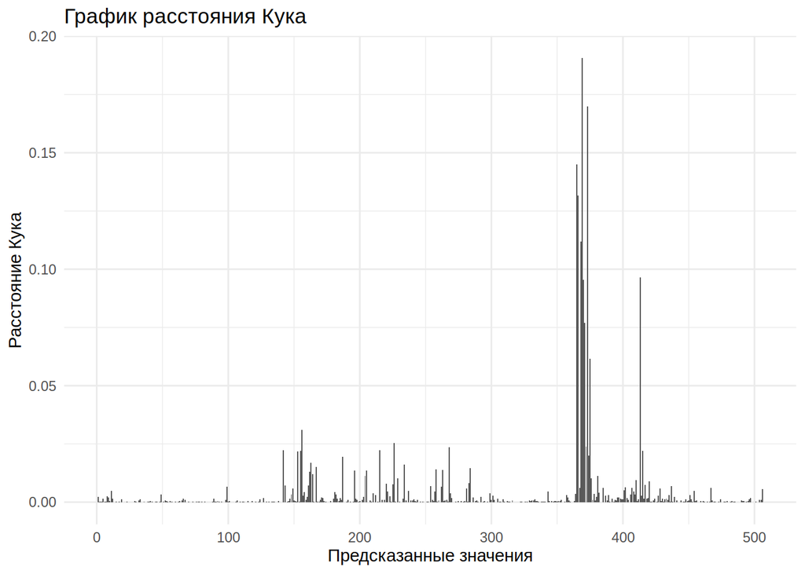

Все хорошо, влиятельные наблюдения отсутствуют.

##### Нормальность распределения остатков

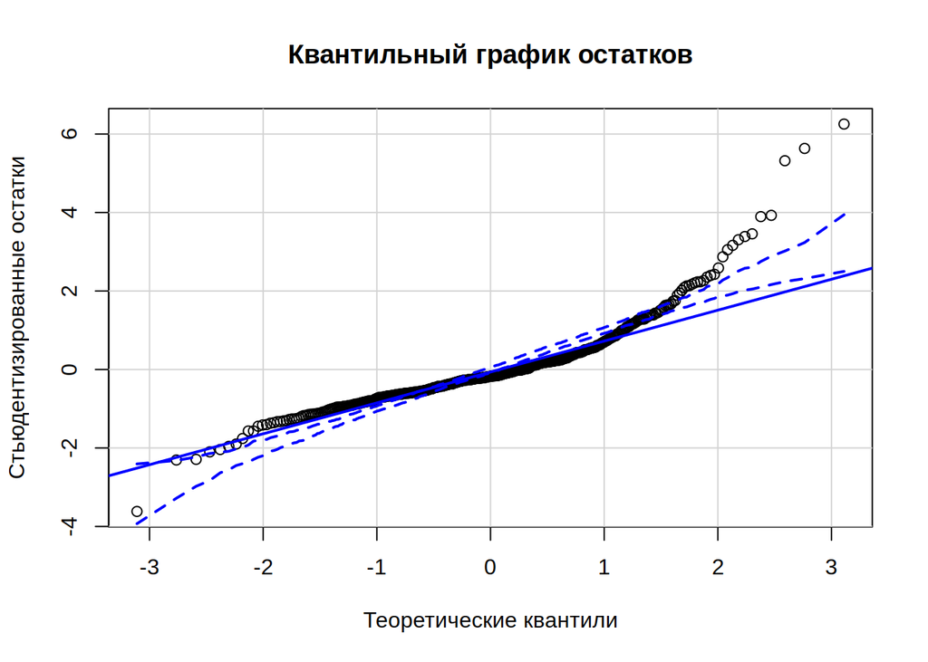

Распределение остатков отклоняется от нормального, что не очень хорошо, но та же ситуация была и в полной модели.

#### Проверка неучтенных зависимостей

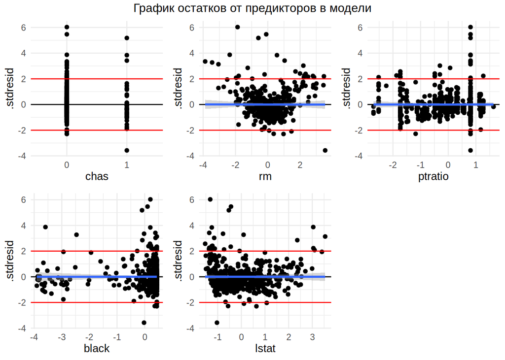

Разберем то, что видим поподробнее. Так как переменная chas является факторной, сказать ничего касательно характера паттерна мы не особо можем. Зависимость остатков от *rm* имеет нелинейный паттерн, что заставляет задуматься о том, что, возможно, линейная модель была использована некорректно. На графиках от *black* и *lstat* также видим легкий нелинейный паттерн.

Что мы могли сделать не так? Возможно, все-таки стоило учитывать взаимодействия предикторов…

Посмотрим еще раз на нашу финальную модель:

```
##
## Call:
## lm(formula = medv ~ chas + rm + ptratio + black + lstat, data = scaled_Boston)
##
## Residuals:
##      Min       1Q   Median       3Q      Max
## -17.6281  -2.9377  -0.8882   1.5061  30.2533
##
## Coefficients:
##             Estimate Std. Error t value Pr(>|t|)
## (Intercept)  22.3032     0.2350  94.914  < 2e-16 ***
## chas1         3.3200     0.9015   3.683 0.000256 ***
## rm            3.2688     0.2951  11.076  < 2e-16 ***
## ptratio      -1.8581     0.2500  -7.432 4.67e-13 ***
## black         0.9232     0.2466   3.743 0.000203 ***
## lstat        -3.6995     0.3137 -11.792  < 2e-16 ***
## ---
## Signif. codes:  0 '***' 0.001 '**' 0.01 '*' 0.05 '.' 0.1 ' ' 1
##
## Residual standard error: 5.096 on 500 degrees of freedom
## Multiple R-squared:  0.696,  Adjusted R-squared:  0.693
## F-statistic: 228.9 on 5 and 500 DF,  p-value: < 2.2e-16
```

Наибольший по модулю коэффициент обладает переменная **lstat**. Построим от нее график предсказания стоимости:

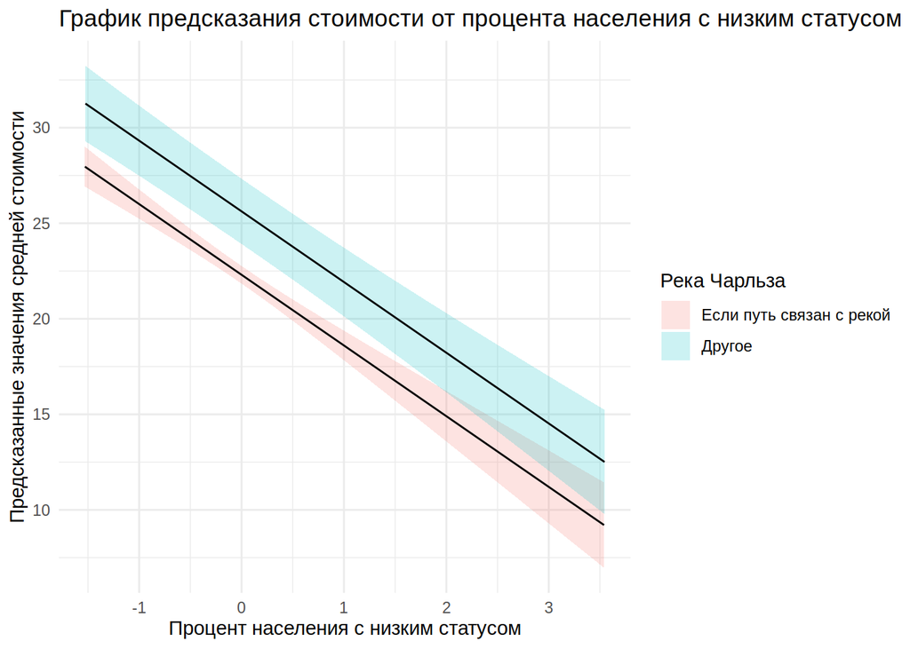

Запишем наше уравнение линейной модели:

[output not shown]

Всё!